# WastewaterRe Code Summary

Karim El-Ouaghlidi

4/25/2022

# Summary of code used in WastewaterRe Paper by Huisman et. al (file wastewater_Zurich.R)

# - Initial data manipulation (outside of complicated, nested functions)

## - Wastewater (“Flow”) data

- flow data is loaded with col_names = c(‘date’, ‘cases’, ‘cases_smooth’,‘flow’, ‘n1_smooth’, ‘n2_smooth’)
- gene data is loaded with col_names = c(‘date’, ‘n1’, ‘n2’),
- missing values in flow data are imputed by linear interpolation:

```r
raw_data_ZH <- raw_flow_data_ZH %>%
  left_join(raw_gene_data_ZH, c('date')) %>%
  filter(!is.na(n1),
         date >= as_date("2020-09-01"),
         date <= as_date("2021-01-20"),
         date != as_date("2020-10-29")) %>%
  mutate(orig_data = TRUE) %>%
  complete(date = seq.Date(min(date), max(date), by = 'days')) %>%
  mutate(across(where(is.numeric), ~ zoo::na.approx(.x, na.rm = F) )) %>%
  mutate(region = 'ZH')
```

## - Case data

- Catchment level clinical case data: missing values are set to 0
- Intuition: a positive case is most likely reported for the next day if the actual day was missing

```r
orig_cases <- read_csv(paste0(dir,'/wastewaterRe/data/ZH_case_incidence_data.csv')) %>%
  filter(date >= as_date("2020-08-15"),
         date <= as_date("2021-01-20")) %>%
  mutate(across(c(-date), ~ ifelse(is.na(.), 0, .)))  %>%
  select(date, confirmed)
```

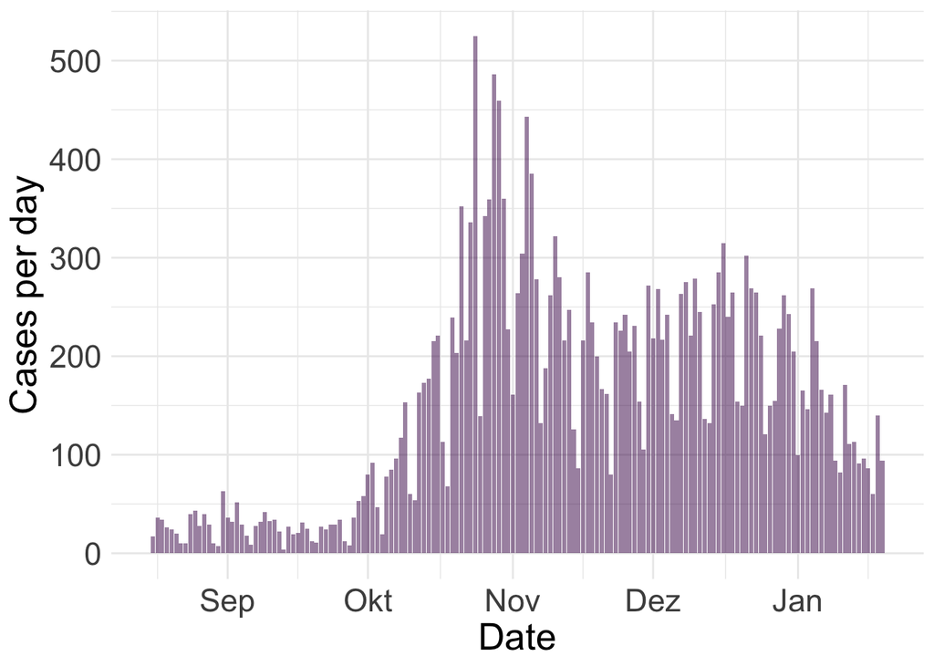

# - Deconvolution of Case data

- Let $C$ denote the observed cases and $D$ denote the delay distribution (“transfer function”) from true underlying incidence $I_{cc}$ to $C$.
- Then, $C = I_{cc} \ast D$ is the convolution of true incidence $I_{cc}$ and delay function $D$.
- Thus, in order to obtain an estimate for the underlying true incidence, which we want to use to obtain our Shedding Load Distribution (SLD), we need to do a deconvolution of observed cases and delay distribution.

```r
deconv_cases <- data.frame()
Re_cases <- data.frame()
for(inc_var in c('confirmed')){
  new_deconv_data = deconvolveIncidence(orig_cases,
                                        incidence_var = inc_var,
                                        getCountParams('incubation'),
                                        getCountParams(paste0(inc_var, '_zh')),
                                        smooth_param = TRUE, n_boot = 50)
  new_Re = getReBootstrap(new_deconv_data)

  deconv_cases <- bind_rows(deconv_cases, new_deconv_data)
  Re_cases = bind_rows(Re_cases, new_Re)
}
```

```
## estimating Re for data source:  ETH ...
##   Region:  CHE
##     Data type:  infection_confirmed
```

## deconvolveIncidence()

- Let’s have a closer look at the called function wrapper:

```r
deconvolveIncidence <- function(df, incidence_var = 'n1',
                                IncubationParams, OnsetToCountParams,
                                smooth_param = FALSE, n_boot = 50){
  infection_df <- addUselessColumns(df, inc_var = incidence_var)

  constant_delay_distributions <- list("Simulated" = get_vector_constant_waiting_time_distr(
    IncubationParams$shape, IncubationParams$scale,
    OnsetToCountParams$shape, OnsetToCountParams$scale),
    "Symptoms" = get_vector_constant_waiting_time_distr(
      IncubationParams$shape, IncubationParams$scale,
      0, 0))

  estimatedInfections <- get_infection_incidence_by_deconvolution(
    infection_df,
    is_local_cases = T,
    constant_delay_distribution = constant_delay_distributions[['Simulated']],
    constant_delay_distribution_incubation = constant_delay_distributions[["Symptoms"]],
    max_iterations = 100,
    smooth_incidence = smooth_param,
    empirical_delays = tibble(),
    n_bootstrap = n_boot,
    verbose = FALSE)

  return(estimatedInfections)
}
```

- Apparently, the actual deconvolution function takes as input the infection time series, and the delay distributions 1) incubation and 2) symptom onset to reporting as vectors that sum up to 1.

```r
inc_var <- "confirmed"

IncubationParams <- getCountParams('incubation')
OnsetToCountParams <- getCountParams(paste0(inc_var, '_zh'))

constant_delay_distributions <- list("Simulated" = get_vector_constant_waiting_time_distr(
    IncubationParams$shape, IncubationParams$scale,
    OnsetToCountParams$shape, OnsetToCountParams$scale),
    "Symptoms" = get_vector_constant_waiting_time_distr(
      IncubationParams$shape, IncubationParams$scale,
      0, 0))

constant_delay_distributions
```

```
## $Simulated
##   [1] 0.000275 0.010087 0.036380 0.067364 0.090384 0.102973 0.106027 0.101272
##   [9] 0.091444 0.080124 0.066937 0.054857 0.044261 0.035209 0.027313 0.020951
##  [17] 0.016130 0.012321 0.009203 0.006897 0.005206 0.003784 0.002820 0.002059
##  [25] 0.001598 0.001098 0.000828 0.000586 0.000452 0.000309 0.000240 0.000158
##  [33] 0.000128 0.000093 0.000062 0.000037 0.000024 0.000029 0.000028 0.000020
##  [41] 0.000010 0.000007 0.000006 0.000000 0.000003 0.000001 0.000001 0.000000
##  [49] 0.000002 0.000000 0.000000 0.000000 0.000000 0.000001 0.000000 0.000000
##  [57] 0.000000 0.000001 0.000000 0.000000 0.000000 0.000000 0.000000 0.000000
##  [65] 0.000000 0.000000 0.000000 0.000000 0.000000 0.000000 0.000000 0.000000
##  [73] 0.000000 0.000000 0.000000 0.000000 0.000000 0.000000 0.000000 0.000000
##  [81] 0.000000 0.000000 0.000000 0.000000 0.000000 0.000000 0.000000 0.000000
##  [89] 0.000000 0.000000 0.000000 0.000000 0.000000 0.000000 0.000000 0.000000
##  [97] 0.000000 0.000000 0.000000 0.000000 0.000000 0.000000 0.000000 0.000000
## [105] 0.000000 0.000000 0.000000 0.000000 0.000000 0.000000 0.000000 0.000000
```

[output cut: 38 more lines]

```r
sum(constant_delay_distributions[[1]])
```

```
## [1] 1
```

```r
sum(constant_delay_distributions[[2]])
```

```
## [1] 1
```

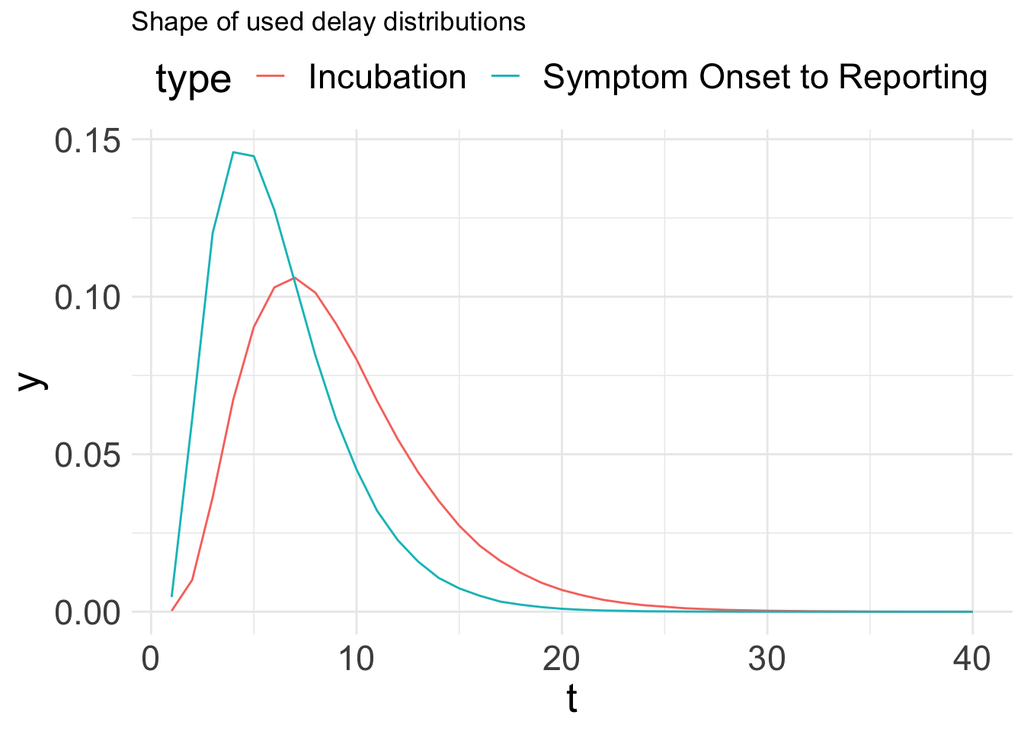

```r
T_max <- 40

delay_distribution_inc <- tibble(t = 1:T_max,
                              y = constant_delay_distributions[[1]][1:T_max],
                              type = 'Incubation')


delay_distribution_sym <- tibble(t = 1:T_max,
                                 y = constant_delay_distributions[[2]][1:T_max],
                                 type = 'Symptom Onset to Reporting')


delay_distributions <- c(list(delay_distribution_inc),list(delay_distribution_sym)) %>%
  dplyr::bind_rows()

ggplot(delay_distributions) +
  geom_line(aes(x=t, y= y, color = type)) +
  ggtitle("Shape of used delay distributions")
```

- detail question: What goes on inside the following function?! I know what the result is so this is not too important to sort out :)

```r
get_vector_constant_waiting_time_distr <- function(shape_incubation,
                                                   scale_incubation,
                                                   shape_onset_to_report,
                                                   scale_onset_to_report,
                                                   length_out = 200,
                                                   n_random_samples = 1E6) {

  F_h <- make_ecdf_from_gammas(shape = c(shape_incubation, shape_onset_to_report),
                               scale = c(scale_incubation, scale_onset_to_report))

  f <- Vectorize(function(x){
    if(x < 0) {
      return(0)
    } else if(x < 0.5) {
      return(F_h(0.5))
    } else {
      return(F_h(round(x + 1E-8) + 0.5) - F_h(round(x + 1E-8) - 0.5))
    }
  })

# Where the following function is called
make_ecdf_from_gammas <- function(shape, scale, numberOfSamples = 1E6) {
  draws <-
    rgamma(numberOfSamples, shape = shape[1], scale = scale[1]) +
    rgamma(numberOfSamples, shape = shape[2], scale = scale[2])
  return(Vectorize(ecdf(draws)))
}
```

## get_infection_incidence_by_deconvolution()

```r
## Actual deconvolution function..

get_infection_incidence_by_deconvolution <- function(
  data_subset,
  constant_delay_distribution,
  constant_delay_distribution_incubation = c(),
  is_onset_data = F,
  is_local_cases = T,
  smooth_incidence = T,
  days_incl = 21,
  empirical_delays  = tibble(),
  n_bootstrap = 5,
  days_further_in_the_past = 30,
  days_further_in_the_past_incubation = 5,
  max_iterations = 100,
  verbose = FALSE) {

  #TODO make the days_further_in_the_past type specific

  if(nrow(data_subset) == 0) {
    return(tibble())
  }

  data_type_subset <- unique(data_subset$data_type)[1]

  # exclude leading zeroes
  data_subset <- data_subset %>%
    arrange(date) %>%
    filter(cumsum(value) > 0)

  if(nrow(data_subset) == 0) {
    return(tibble())
  }

  minimal_date <- min(data_subset$date) - days_further_in_the_past
  maximal_date <- max(data_subset$date)
  all_dates <- seq(minimal_date, maximal_date, by = "days")

  is_empirical = (nrow(empirical_delays) > 0)

  if(verbose && is_empirical) {
    cat("\tEmpirical delay distribution available\n")
  }

# We can ignore this as default setting is_onset_data = FALSE

#   if( is_onset_data ) {
#     delay_distribution_matrix_incubation <- get_matrix_constant_waiting_time_distr(
#       constant_delay_distribution_incubation,
#       all_dates)
#
#     initial_delta_incubation <- min(which(cumsum(constant_delay_distribution_incubation) > 0.5)) - 1 # take median value (-1 because index 1 corresponds to zero days)
#
#
#     if(unique(data_subset$region)[1] != "ESP") { # hack to workaround weirdness of Spanish data
#
#       # account for additional right-truncation of onset data (needs to be reported first)
#       if(is_empirical) {
#         delay_distribution_matrix_onset_to_report <- get_matrix_empirical_waiting_time_distr(
#           empirical_delays,
#           seq.Date(min(data_subset$date), max(data_subset$date), by = "days"))
#       } else {
#         delay_distribution_matrix_onset_to_report <- get_matrix_constant_waiting_time_distr(
#           constant_delay_distribution,
#           seq.Date(min(data_subset$date), max(data_subset$date), by = "days"))
#       }
#
#       data_subset <- data_subset %>%
#         complete(date = seq.Date(min(date), max(date), by = "days"), fill = list(value = 0))
#
#       Q_vector_onset_to_report <- apply(delay_distribution_matrix_onset_to_report, MARGIN = 2, sum)
#
#       #TODO remove
#       # if(unique(data_subset$region)[1] == "ESP") { # hack to work around spanish data between symptom onset dates only
#       #   right_truncation <- 3
#       #   # need to offset the Q vector by how many days were truncated off originally
#       #   Q_vector_onset_to_report <- c(rep(1, right_truncation), Q_vector_onset_to_report[1:(length(Q_vector_onset_to_report) - right_truncation)] )
#       # }
#
#       data_subset <- data_subset %>%
#         mutate(value = value / Q_vector_onset_to_report) %>%
#         mutate(value = if_else(value == Inf, 0, value))
#
#     }
#
#   } else {


# Also, is_empirical = FALSE per default and we don't supply empirical delays.

    # if(is_empirical) {
    #   delay_distribution_matrix_onset_to_report <- get_matrix_empirical_waiting_time_distr(
    #     empirical_delays,
    #     all_dates[(days_further_in_the_past_incubation + 1):length(all_dates)])
    #
    #   delay_distribution_matrix_incubation <- get_matrix_constant_waiting_time_distr(
    #     constant_delay_distribution_incubation,
    #     all_dates)
    #
    #   initial_delta_incubation <- min(which(cumsum(constant_delay_distribution_incubation) > 0.5)) - 1 # take median value (-1 because index 1 corresponds to zero days)
    #   initial_delta_report <-  median(empirical_delays$delay, na.rm = T)
    # } else {


      delay_distribution_matrix <- get_matrix_constant_waiting_time_distr(
        constant_delay_distribution,
        all_dates)

      initial_delta <- min(which(cumsum(constant_delay_distribution) > 0.5)) - 1
      # take median value (-1 because index 1 corresponds to zero days)

  #   }
  # }



  results <- list(tibble())
  ## bootstrapping is performed on the log_diff = log_value - log_loess
  ## and is converted back to original scale afterwards
  for (bootstrap_replicate_i in 0:n_bootstrap) {

    if (verbose == T) {
      cat("    Bootstrap replicate: ", bootstrap_replicate_i, "\n")
    }

    if (bootstrap_replicate_i == 0) {
      time_series <- data_subset
    } else {
      time_series <- get_bootstrap_replicate(data_subset)
    }
## Now, the original or bootstrapped time series is smoothed by LOESS
    if (smooth_incidence == T) {
      smoothed_incidence_data <- time_series %>%
        complete(date = seq.Date(min(date), max(date), by = "days"),
                 fill = list(value = 0)) %>%
        mutate(value = getLOESSCases(dates = date, count_data = value, days_incl))

      raw_total_incidence <- sum(time_series$value, na.rm = TRUE)
      smoothed_total_incidence <- sum(smoothed_incidence_data$value, na.rm = T)
## Reweighting to make sure that sums match??
      if (smoothed_total_incidence > 0) {
        smoothed_incidence_data <- smoothed_incidence_data %>%
          mutate(value = value * raw_total_incidence / smoothed_total_incidence)
      }

    } else {
      smoothed_incidence_data <- time_series  %>%
        complete(date = seq.Date(min(date), max(date), by = "days"),
                 fill = list(value = 0))
    }
    # is_onset_data = FALSE per default

    # if (is_onset_data) {
    #   deconvolved_infections <-  do_deconvolution(smoothed_incidence_data,
    #                                               delay_distribution_matrix = delay_distribution_matrix_incubation,
    #                                               days_further_in_the_past = days_further_in_the_past,
    #                                               initial_delta = initial_delta_incubation,
    #                                               max_iterations = max_iterations,
    #                                               verbose = verbose)
    # } else {


    # is_empirical = FALSE as well in our setting

      # if(is_empirical) {
      #   # perform the deconvolution in two steps
      #   deconvolved_symptom_onsets <- do_deconvolution(smoothed_incidence_data,
      #                                                  delay_distribution_matrix = delay_distribution_matrix_onset_to_report,
      #                                                  days_further_in_the_past = days_further_in_the_past - days_further_in_the_past_incubation,
      #                                                  initial_delta = initial_delta_report,
      #                                                  max_iterations = max_iterations,
      #                                                  verbose = verbose)
      #
      #   deconvolved_infections <- do_deconvolution(deconvolved_symptom_onsets,
      #                                              delay_distribution_matrix = delay_distribution_matrix_incubation,
      #                                              days_further_in_the_past = days_further_in_the_past_incubation,
      #                                              initial_delta = initial_delta_incubation,
      #                                              max_iterations = max_iterations,
      #                                              verbose = verbose)
      # } else {

        deconvolved_infections <-  do_deconvolution(smoothed_incidence_data,
                                      delay_distribution_matrix = delay_distribution_matrix,
                                      days_further_in_the_past = days_further_in_the_past,
                                      initial_delta = initial_delta,
                                      max_iterations = max_iterations,
                                      verbose = verbose)

    #   }
    # }


    deconvolved_infections <- deconvolved_infections %>%
      slice((days_further_in_the_past -5 + 1):n())

    data_type_name <- paste0("infection_", data_type_subset)

    ## dataframe containing results
    deconvolved_infections <- tibble(
      date = deconvolved_infections$date,
      region = unique(time_series$region)[1],
      country = unique(time_series$country)[1],
      source = unique(time_series$source)[1],
      local_infection = is_local_cases,
      data_type = data_type_name,
      replicate = bootstrap_replicate_i,
      value = deconvolved_infections$value
    )

    results <- c(results, list(deconvolved_infections))
  }

  return(bind_rows(results))
}
```

- Essentially, what happens is: the wrapper function creates the vectors of delay distributions for 1) incubation and 2) symptom onset to reporting and supplies it to the actual deconvolution function. Then, the function `get_matrix_constant_waiting_time_distr` creates a T by T lower-diagonal matrix with the vectorized delay distributions as columns starting at the diagonal element (see below for illustration).
- bootstrapping is performed on `log_diff = log_value - log_loess` where `log_value = log(value + 1)`. Afterwards, the bootstrapped time series is transformed back to original scale: `ts_boot = exp(log_diff + log_loess) - 1`. In each of the `n_bootstrap = 50` iterations, the deconvolution is performed.

```r
get_matrix_constant_waiting_time_distr <- function(waiting_time_distr,
                                                   all_dates) {
  N <- length(all_dates)

  if(length(all_dates) >= length(waiting_time_distr)) {
    waiting_time_distr <- c(waiting_time_distr, rep(0, times = N - length(waiting_time_distr)))
  }

  delay_distribution_matrix <- matrix(0, nrow = N, ncol = N)
  for(i in 1:N) {
    delay_distribution_matrix[, i ] <-  c(rep(0, times = i - 1 ), waiting_time_distr[1:(N - i + 1)])
  }

  return(delay_distribution_matrix)
}
```

- Let’s check what shape the returned matrix `delay_distribution_matrix` has:

```r
constant_delay_distributions <- list("Simulated" = get_vector_constant_waiting_time_distr(
    IncubationParams$shape, IncubationParams$scale,
    OnsetToCountParams$shape, OnsetToCountParams$scale),
    "Symptoms" = get_vector_constant_waiting_time_distr(
      IncubationParams$shape, IncubationParams$scale,
      0, 0))

constant_delay_distribution <- constant_delay_distributions[['Simulated']]

constant_delay_distribution_incubation <- constant_delay_distributions[["Symptoms"]]

dates_seq <- seq(date("2021-01-01"), date("2021-01-01")+6, by = "days")

# Check Matrix for small N
get_matrix_constant_waiting_time_distr(
        constant_delay_distribution,
        dates_seq)
```

```
##          [,1]     [,2]     [,3]     [,4]     [,5]     [,6]     [,7]
## [1,] 0.000252 0.000000 0.000000 0.000000 0.000000 0.000000 0.000000
## [2,] 0.010223 0.000252 0.000000 0.000000 0.000000 0.000000 0.000000
## [3,] 0.036709 0.010223 0.000252 0.000000 0.000000 0.000000 0.000000
## [4,] 0.066966 0.036709 0.010223 0.000252 0.000000 0.000000 0.000000
## [5,] 0.090936 0.066966 0.036709 0.010223 0.000252 0.000000 0.000000
## [6,] 0.102985 0.090936 0.066966 0.036709 0.010223 0.000252 0.000000
## [7,] 0.105920 0.102985 0.090936 0.066966 0.036709 0.010223 0.000252
```

```r
# Verify that Matrix indeed only includes vectorized delay distribution
all.equal(constant_delay_distribution[1:7],
        get_matrix_constant_waiting_time_distr(
        constant_delay_distribution, dates_seq)[,1])
```

```
## [1] TRUE
```

### - “stepwise” function call

```r
days_further_in_the_past <- 30

incidence_var <- inc_var <- 'confirmed'

head(orig_cases)
```

| date | confirmed |
| --- | --- |
| 2020-08-15 | 10 |
| 2020-08-16 | 17 |
| 2020-08-17 | 36 |
| 2020-08-18 | 34 |
| 2020-08-19 | 26 |
| 2020-08-20 | 24 |

```r
data_subset <- infection_df <- addUselessColumns(orig_cases, inc_var = incidence_var)

  # exclude leading zeroes
  data_subset <- data_subset %>%
    arrange(date) %>%
    filter(cumsum(value) > 0)

head(data_subset)
```

| date | region | value | data_type | source | variable | country | date_type | local_infection |
| --- | --- | --- | --- | --- | --- | --- | --- | --- |
| 2020-08-15 | CHE | 10 | confirmed | ETH | incidence | Switzerland | report | TRUE |
| 2020-08-16 | CHE | 17 | confirmed | ETH | incidence | Switzerland | report | TRUE |
| 2020-08-17 | CHE | 36 | confirmed | ETH | incidence | Switzerland | report | TRUE |
| 2020-08-18 | CHE | 34 | confirmed | ETH | incidence | Switzerland | report | TRUE |
| 2020-08-19 | CHE | 26 | confirmed | ETH | incidence | Switzerland | report | TRUE |
| 2020-08-20 | CHE | 24 | confirmed | ETH | incidence | Switzerland | report | TRUE |

```r
  minimal_date <- min(data_subset$date) - days_further_in_the_past
  maximal_date <- max(data_subset$date)
  all_dates <- seq(minimal_date, maximal_date, by = "days")

# Create actual delay_distribution_matrix
delay_distribution_matrix <- get_matrix_constant_waiting_time_distr(constant_delay_distribution,all_dates)

#
initial_delta <- min(which(cumsum(constant_delay_distribution) > 0.5)) - 1
```

## - Smoothing by LOESS

```r
days_incl = 21
time_series <- data_subset
smoothed_incidence_data <- time_series %>%
        complete(date = seq.Date(min(date), max(date), by = "days"),
                 fill = list(value = 0)) %>%
        mutate(value = getLOESSCases(dates = date, count_data = value, days_incl))

      raw_total_incidence <- sum(time_series$value, na.rm = TRUE)
      smoothed_total_incidence <- sum(smoothed_incidence_data$value, na.rm = T)
## Reweighting to make sure that sums match
      if (smoothed_total_incidence > 0) {
        smoothed_incidence_data <- smoothed_incidence_data %>%
          mutate(value = value * raw_total_incidence / smoothed_total_incidence)
      }

sum(smoothed_incidence_data$value) == raw_total_incidence
```

```
## [1] TRUE
```

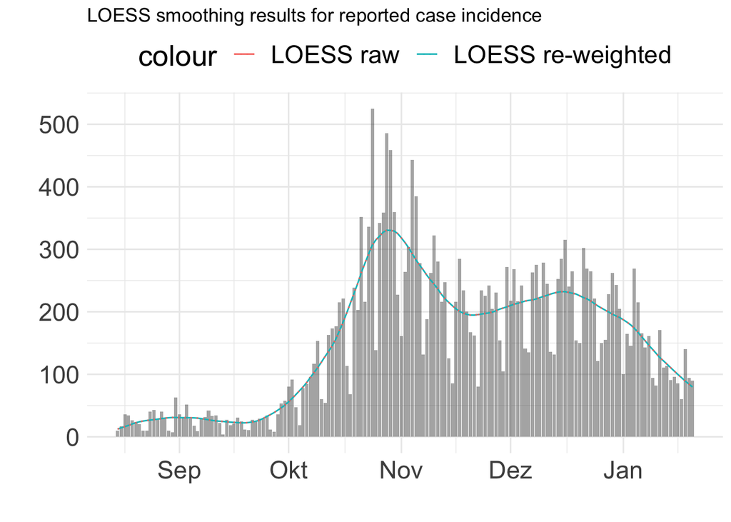

```r
smoothed_incidence_data_raw <- time_series %>%
        complete(date = seq.Date(min(date), max(date), by = "days"),
                 fill = list(value = 0)) %>%
        mutate(value = getLOESSCases(dates = date, count_data = value, days_incl))

ggplot() +
  geom_bar(aes(x=date, y= value), data = time_series, alpha = 0.5, show.legend = F,
             position = 'identity', stat = 'identity') +
  # geom_line(aes(x = date, y = value, color = 'raw'), data = time_series) +
  geom_line(aes(x= date, y = value, color = 'LOESS re-weighted'), data = smoothed_incidence_data) +
  geom_line(aes(x= date, y = value, color = 'LOESS raw'), linetype = 'dotted', data = smoothed_incidence_data_raw) +
  ggtitle('LOESS smoothing results for reported case incidence')+
  ylab('')+
  xlab('')
```

## do_deconvolution()

- After putting together the necessary inputs the actual deconvolution function `do_deconvolution()` is called.
  - `smoothed_incidence_data`
  - `delay_distribution_matrix`
  - `initial_delta`: index at which cumsum of delay distribution vector exceeds median
- `do_deconvolution()` function:

```r
do_deconvolution <- function(
  incidence_data,
  days_further_in_the_past = 30,
  verbose = FALSE,
  delay_distribution_matrix,
  initial_delta,
  max_iterations = 100
) {

  # use mode of 'constant_delay_distribution'. -1 because indices are offset by one as the delay can be 0.

  first_guess_delay <- ceiling(initial_delta)

  if (verbose) {
    cat("\tDelay on first guess: ", first_guess_delay, "\n")
  }

  first_recorded_incidence <-  with(filter(incidence_data, cumsum(value) > 0), value[which.min(date)])
  last_recorded_incidence <- with(incidence_data, value[which.max(date)])

  minimal_date <- min(incidence_data$date) - days_further_in_the_past
  maximal_date <- max(incidence_data$date)

  first_guess <- incidence_data %>%
    mutate(date = date - first_guess_delay) %>%
    complete(date = seq.Date(minimal_date, min(date), by = "days"),
             fill = list(value = first_recorded_incidence)) %>% # left-pad with first recorded value
    complete(date = seq.Date(max(date), maximal_date, by = "days"),
             fill = list(value = last_recorded_incidence)) %>% # right-pad with last recorded value
    arrange(date) %>%
    filter(date >=  minimal_date)

  original_incidence <- incidence_data %>%
    complete(date = seq.Date(minimal_date, maximal_date, by = "days"),
             fill = list(value = 0)) %>%
    pull(value)

  final_estimate <- iterate_RL(
    first_guess$value,
    original_incidence,
    delay_distribution_matrix = delay_distribution_matrix,
    max_delay = days_further_in_the_past,
    max_iterations = max_iterations,
    verbose = verbose)

  deconvolved_dates <- first_guess %>% pull(date)

  result <- tibble(date = deconvolved_dates, value = final_estimate)

  result <- result %>%
    filter(date <= maximal_date - first_guess_delay)

  return(result)
}
```

### - Stepwise function call

```r
# setting function arguments
bootstrap_replicate_i <- 0 # looping index
max_iterations <- 100
verbose <- FALSE
data_type_subset <- unique(data_subset$data_type)[1]
is_local_cases <- TRUE
incidence_data <- smoothed_incidence_data



  # use mode of 'constant_delay_distribution'. -1 because indices are offset by one as the delay can be 0.

  (first_guess_delay <- ceiling(initial_delta))
```

```
## [1] 7
```

```r
  if (verbose) {
    cat("\tDelay on first guess: ", first_guess_delay, "\n")
  }

  (first_recorded_incidence <-  with(filter(incidence_data, cumsum(value) > 0), value[which.min(date)]))
```

```
## [1] 12.38484
```

```r
  (last_recorded_incidence <- with(incidence_data, value[which.max(date)]))
```

```
## [1] 79.74476
```

```r
  minimal_date <- min(incidence_data$date) - days_further_in_the_past
  maximal_date <- max(incidence_data$date)

  incidence_data %>%
    head(10)
```

| date | region | value | data_type | source | variable | country | date_type | local_infection |
| --- | --- | --- | --- | --- | --- | --- | --- | --- |
| 2020-08-15 | CHE | 12.38484 | confirmed | ETH | incidence | Switzerland | report | TRUE |
| 2020-08-16 | CHE | 14.50464 | confirmed | ETH | incidence | Switzerland | report | TRUE |
| 2020-08-17 | CHE | 16.37072 | confirmed | ETH | incidence | Switzerland | report | TRUE |
| 2020-08-18 | CHE | 18.30220 | confirmed | ETH | incidence | Switzerland | report | TRUE |
| 2020-08-19 | CHE | 20.46393 | confirmed | ETH | incidence | Switzerland | report | TRUE |
| 2020-08-20 | CHE | 22.53302 | confirmed | ETH | incidence | Switzerland | report | TRUE |
| 2020-08-21 | CHE | 24.09706 | confirmed | ETH | incidence | Switzerland | report | TRUE |
| 2020-08-22 | CHE | 25.20855 | confirmed | ETH | incidence | Switzerland | report | TRUE |
| 2020-08-23 | CHE | 26.15154 | confirmed | ETH | incidence | Switzerland | report | TRUE |
| 2020-08-24 | CHE | 26.86094 | confirmed | ETH | incidence | Switzerland | report | TRUE |

```r
  incidence_data %>%
    tail(10)
```

| date | region | value | data_type | source | variable | country | date_type | local_infection |
| --- | --- | --- | --- | --- | --- | --- | --- | --- |
| 2021-01-11 | CHE | 126.84979 | confirmed | ETH | incidence | Switzerland | report | TRUE |
| 2021-01-12 | CHE | 121.66680 | confirmed | ETH | incidence | Switzerland | report | TRUE |
| 2021-01-13 | CHE | 116.22517 | confirmed | ETH | incidence | Switzerland | report | TRUE |
| 2021-01-14 | CHE | 110.58843 | confirmed | ETH | incidence | Switzerland | report | TRUE |
| 2021-01-15 | CHE | 105.15540 | confirmed | ETH | incidence | Switzerland | report | TRUE |
| 2021-01-16 | CHE | 99.69991 | confirmed | ETH | incidence | Switzerland | report | TRUE |
| 2021-01-17 | CHE | 94.55805 | confirmed | ETH | incidence | Switzerland | report | TRUE |
| 2021-01-18 | CHE | 89.32939 | confirmed | ETH | incidence | Switzerland | report | TRUE |
| 2021-01-19 | CHE | 84.34623 | confirmed | ETH | incidence | Switzerland | report | TRUE |
| 2021-01-20 | CHE | 79.74476 | confirmed | ETH | incidence | Switzerland | report | TRUE |

```r
  first_guess <- incidence_data %>%
    mutate(date = date - first_guess_delay) %>%
    complete(date = seq.Date(minimal_date, min(date), by = "days"),
             fill = list(value = first_recorded_incidence)) %>% # left-pad with first recorded value
    complete(date = seq.Date(max(date), maximal_date, by = "days"),
             fill = list(value = last_recorded_incidence)) %>% # right-pad with last recorded value
    arrange(date) %>%
    filter(date >=  minimal_date)

  first_guess %>%
    head(10)
```

| date | region | value | data_type | source | variable | country | date_type | local_infection |
| --- | --- | --- | --- | --- | --- | --- | --- | --- |
| 2020-07-16 | NA | 12.38484 | NA | NA | NA | NA | NA | NA |
| 2020-07-17 | NA | 12.38484 | NA | NA | NA | NA | NA | NA |
| 2020-07-18 | NA | 12.38484 | NA | NA | NA | NA | NA | NA |
| 2020-07-19 | NA | 12.38484 | NA | NA | NA | NA | NA | NA |
| 2020-07-20 | NA | 12.38484 | NA | NA | NA | NA | NA | NA |
| 2020-07-21 | NA | 12.38484 | NA | NA | NA | NA | NA | NA |
| 2020-07-22 | NA | 12.38484 | NA | NA | NA | NA | NA | NA |
| 2020-07-23 | NA | 12.38484 | NA | NA | NA | NA | NA | NA |
| 2020-07-24 | NA | 12.38484 | NA | NA | NA | NA | NA | NA |
| 2020-07-25 | NA | 12.38484 | NA | NA | NA | NA | NA | NA |

```r
  first_guess %>%
    tail(10)
```

| date | region | value | data_type | source | variable | country | date_type | local_infection |
| --- | --- | --- | --- | --- | --- | --- | --- | --- |
| 2021-01-11 | CHE | 89.32939 | confirmed | ETH | incidence | Switzerland | report | TRUE |
| 2021-01-12 | CHE | 84.34623 | confirmed | ETH | incidence | Switzerland | report | TRUE |
| 2021-01-13 | CHE | 79.74476 | confirmed | ETH | incidence | Switzerland | report | TRUE |
| 2021-01-14 | NA | 79.74476 | NA | NA | NA | NA | NA | NA |
| 2021-01-15 | NA | 79.74476 | NA | NA | NA | NA | NA | NA |
| 2021-01-16 | NA | 79.74476 | NA | NA | NA | NA | NA | NA |
| 2021-01-17 | NA | 79.74476 | NA | NA | NA | NA | NA | NA |
| 2021-01-18 | NA | 79.74476 | NA | NA | NA | NA | NA | NA |
| 2021-01-19 | NA | 79.74476 | NA | NA | NA | NA | NA | NA |
| 2021-01-20 | NA | 79.74476 | NA | NA | NA | NA | NA | NA |

```r
  original_incidence <- incidence_data %>%
    complete(date = seq.Date(minimal_date, maximal_date, by = "days"),
             fill = list(value = 0)) %>%
    pull(value)



  final_estimate <- iterate_RL(
    first_guess$value,
    original_incidence,
    delay_distribution_matrix = delay_distribution_matrix,
    max_delay = days_further_in_the_past,
    max_iterations = max_iterations,
    verbose = verbose)

  deconvolved_dates <- first_guess %>% pull(date)

  result <- tibble(date = deconvolved_dates, value = final_estimate)

  result <- result %>%
    filter(date <= maximal_date - first_guess_delay)

  restult_RL <- result
```

## iterate_RL()

### - Function

```r
iterate_RL <- function(
  initial_estimate,
  original_incidence,
  delay_distribution_matrix,
  threshold_chi_squared = 1,
  max_iterations = 100,
  max_delay,
  verbose = FALSE) {

  current_estimate <- initial_estimate
  N <- length(current_estimate)
  N0 <- N - max_delay
  chi_squared <- Inf
  count <- 1

  delay_distribution_matrix <- delay_distribution_matrix[1:length(current_estimate), 1:length(current_estimate)]
  truncated_delay_distribution_matrix <- delay_distribution_matrix[(1 + max_delay):NROW(delay_distribution_matrix),, drop = F]

  Q_vector <- apply(truncated_delay_distribution_matrix, MARGIN = 2, sum)

  while(chi_squared > threshold_chi_squared & count <= max_iterations) {

    if (verbose) {
      cat("\t\tStep: ", count, " - Chi squared: ", chi_squared, "\n")
    }

    E <- as.vector(delay_distribution_matrix %*% current_estimate)
    B <- replace_na(original_incidence/E, 0)

    current_estimate <- current_estimate / Q_vector *  as.vector(crossprod(B, delay_distribution_matrix))
    current_estimate <- replace_na(current_estimate, 0)

    chi_squared <- 1/N0 * sum((E[(max_delay + 1): length(E)] - original_incidence[(max_delay + 1) : length(original_incidence)])^2/E[(max_delay + 1): length(E)], na.rm = T)
    count <- count + 1
  }

  return(current_estimate)
}
```

### - Stepwise examination

```r
# setting missing arguments
initial_estimate <- first_guess$value
max_delay <- days_further_in_the_past
threshold_chi_squared <- 1

# initialize RL algorithm: starting value is
  current_estimate <- initial_estimate
  # length of output series
  N <- length(current_estimate)
  # length of original series
  N0 <- N - max_delay
  chi_squared <- Inf
  count <- 1

  # subset delay_distribution_matrix
  delay_distribution_matrix <- delay_distribution_matrix[1:length(current_estimate), 1:length(current_estimate)]

  # subset delay_distribution_matrix to obtain a 159 x 189 matrix
  # in order to compute weighting vector
  truncated_delay_distribution_matrix <- delay_distribution_matrix[(1 + max_delay):NROW(delay_distribution_matrix),, drop = F]

  # column sums (sum of weights from original series to incidence estimate)
  Q_vector <- apply(truncated_delay_distribution_matrix, MARGIN = 2, sum)

  while(chi_squared > threshold_chi_squared & count <= max_iterations) {

    if (verbose) {
      cat("\t\tStep: ", count, " - Chi squared: ", chi_squared, "\n")
    }
    # P x u (wiki)
    E <- as.vector(delay_distribution_matrix %*% current_estimate)
    # d / (P x u)
    B <- replace_na(original_incidence/E, 0)

    current_estimate <- current_estimate / Q_vector *  as.vector(crossprod(B, delay_distribution_matrix))

    current_estimate <- replace_na(current_estimate, 0)


    chi_squared <- 1/N0 * sum((E[(max_delay + 1): length(E)] - original_incidence[(max_delay + 1) : length(original_incidence)])^2/E[(max_delay + 1): length(E)], na.rm = T)
    count <- count + 1
  }

(final_estimate <-  current_estimate)
```

```
##   [1]  11.92485  11.95842  11.95048  11.97824  11.97556  11.97762  11.95916
##   [8]  11.95933  11.98071  11.99111  12.01768  12.02153  12.02852  12.03334
##  [15]  12.03322  12.04807  12.06805  12.08875  12.11439  12.14672  12.18078
##  [22]  12.22431  12.27601  12.33920  14.54193  16.54062  18.66592  21.11117
##  [29]  23.55095  25.51118  26.92997  28.04525  28.79564  29.37591  30.10827
##  [36]  30.86239  31.46257  31.96427  32.20627  32.09490  31.77629  31.50613
##  [43]  31.32534  31.06697  30.72706  30.14167  29.15625  28.00613  26.87481
##  [50]  25.78155  24.81328  24.16670  23.65675  22.99407  22.45025  22.08031
##  [57]  21.59931  21.26479  21.28343  21.79093  22.68998  23.84200  25.73867
##  [64]  28.64327  32.05625  35.34004  38.99363  43.15622  47.46466  52.39794
##  [71]  57.97359  63.92353  70.32475  76.98941  83.58881  91.22648  99.75534
##  [78] 107.86089 116.12808 125.19096 134.48251 143.40848 152.58156 163.96826
##  [85] 177.95130 192.79878 208.68390 225.95377 243.14485 260.72043 280.07368
##  [92] 296.81333 312.71882 327.77153 336.62230 342.02566 347.28033 348.73812
##  [99] 346.22376 342.75969 335.66380 325.82346 315.54029 304.33137 292.18667
## [106] 280.35965 270.25698 260.92170 251.23025 242.87770 235.62680 227.67378
## [113] 218.99214 211.74258 206.04331 200.87834 196.06249 192.31026 190.06066
## [120] 188.72848 188.29479 189.01465 190.56090 192.33499 194.18285 195.91297
## [127] 197.89177 200.82509 203.96987 206.34470 208.71454 211.30308 213.65801
## [134] 215.38138 217.24785 219.17224 220.35995 221.06491 222.60282 224.78903
## [141] 226.64987 228.60474 230.73873 232.65430 234.00521 234.94543 234.70423
## [148] 233.19772 231.63620 229.87243 226.54311 223.13265 220.40430 216.68051
## [155] 211.88590 207.52009 203.71569 200.12827 196.73902 193.13841 190.21245
## [162] 187.57185 183.95893 179.99422 175.50072 169.84352 162.97223 155.62185
## [169] 148.28015 140.55280 133.72233 126.77506 119.83123 114.41248 108.84428
## [176] 103.16869  97.73725  92.31550  87.19117  81.98349  76.99730  72.36969
## [183]  71.90956  71.42566  70.92834  70.45295  70.02231  69.69599  69.65723
```

### - Further stepwise processing

```r
## do_deconvolution()
deconvolved_dates <- first_guess %>%
  pull(date)

  result <- tibble(date = deconvolved_dates, value = final_estimate)

  result <- result %>%
    filter(date <= maximal_date - first_guess_delay)

result %>%
  head(10)
```

| date | value |
| --- | --- |
| 2020-07-16 | 11.92485 |
| 2020-07-17 | 11.95842 |
| 2020-07-18 | 11.95048 |
| 2020-07-19 | 11.97824 |
| 2020-07-20 | 11.97556 |
| 2020-07-21 | 11.97762 |
| 2020-07-22 | 11.95916 |
| 2020-07-23 | 11.95933 |
| 2020-07-24 | 11.98071 |
| 2020-07-25 | 11.99111 |

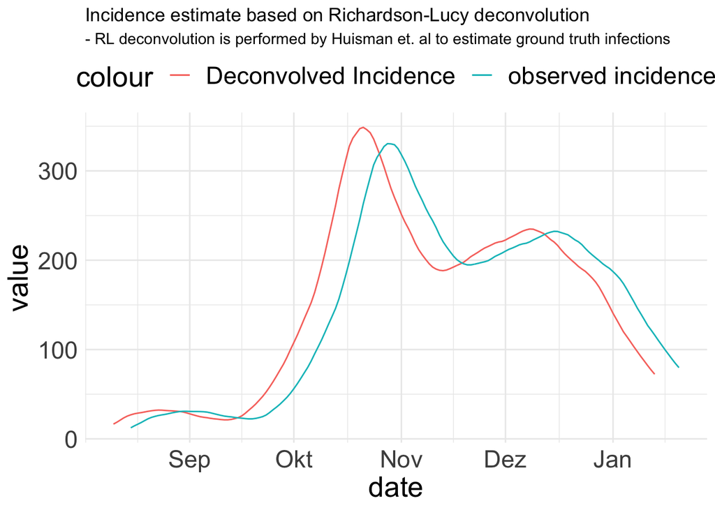

```r
deconvolved_infections <- result
## get_infection_incidence_by_deconvolution()

deconvolved_infections <- deconvolved_infections %>% slice((days_further_in_the_past -5 + 1):n())

    data_type_name <- paste0("infection_", data_type_subset)

    ## dataframe containing results
    deconvolved_infections <- tibble(
      date = deconvolved_infections$date,
      region = unique(time_series$region)[1],
      country = unique(time_series$country)[1],
      source = unique(time_series$source)[1],
      local_infection = is_local_cases,
      data_type = data_type_name,
      replicate = bootstrap_replicate_i,
      value = deconvolved_infections$value
    )


ggplot() +
  geom_line(aes(x = date, y = value, color = "Deconvolved Incidence"), data = deconvolved_infections) +
  geom_line(aes(x = date, y = value, color = "observed incidence"), data = incidence_data) +
  ggtitle("Incidence estimate based on Richardson-Lucy deconvolution",
          subtitle = "- RL deconvolution is performed by Huisman et. al to estimate ground truth infections")
```

## Richardson-Lucy deconvolution applied to cases

- Iterative deconvolution procedure to recover underlying image (or time series in our case) that has been blurred by a *known* point spread function (PSF)
- Converges to the Maximum-Likelihood (MLE) solution under the assumption that the data follows a poisson distribution, which is great for us as we have count data.
- Recall our original deconvolution problem: $C = I_{cc} \ast D$ where we are interested in estimating the ground truth infection incidence time series $I_{cc}$.
- Then, $C_t = \sum_j {\mathbf{P}_{t,j} \cdot{} I_{cc}^j}$ are the observed cases at day t, where $\mathbf{P}$ is `delay_distribution_matrix`. As mentioned above, this matrix is a T by T lower-diagonal matrix with the vectorized delay distributions as columns starting at the diagonal element created by the function `get_matrix_constant_waiting_time_distr()`. (see above for illustration).
- Following the RL algorithm:
  $$I_{cc}^{i+1} = I_{cc}^{i} \left( \frac{C}{ \mathbf P \cdot{} I_{cc}^i } \times \mathbf P \right)$$
  , where the division is elementwise.
- For our purpose, however, we need a small adjustment to correct for the fact that we might observe infections that are not fully transmitted into the wastewater:
  $$I_{cc}^{i+1} = \frac{ I_{cc}^{i} }{ \mathbf{P}^\mathbf T_{ \left[ 31:189,1:189 \right]} \cdot{} \mathbf 1} \left( \frac{C}{ \mathbf P \cdot I_{cc}^i} \times \mathbf P \right)$$

### - RL deconvolution in R

```r
## RL deconvolution in R
  Q_vector <- apply(truncated_delay_distribution_matrix, MARGIN = 2, sum)

  while(chi_squared > threshold_chi_squared & count <= max_iterations) {

    if (verbose) {
      cat("\t\tStep: ", count, " - Chi squared: ", chi_squared, "\n")
    }
    # P x u (wiki)
    E <- as.vector(delay_distribution_matrix %*% current_estimate)
    # d / (P x u)
    B <- replace_na(original_incidence/E, 0)

  current_estimate <- current_estimate / Q_vector *  as.vector(crossprod(B, delay_distribution_matrix))

    current_estimate <- replace_na(current_estimate, 0)


    chi_squared <- 1/N0 * sum((E[(max_delay + 1): length(E)] - original_incidence[(max_delay + 1) : length(original_incidence)])^2/E[(max_delay + 1): length(E)], na.rm = T)
    count <- count + 1
```

# Deconvolution of Wastewater Data

## - Normalisation of Wastewater Data

- Note that this follows after the initial data manipulations presented above.

```r
## Normalisation of WW data ####

# Min observed
norm_min <- min(raw_data_ZH$n1, raw_data_ZH$n2)

### ALL Normalised WW DATA ####
ww_data = bind_rows(raw_data_ZH)  %>%
  mutate(norm_n1 = n1/norm_min,
         norm_n2 = n2/norm_min)

ww_data
```

| date | cases | cases_smooth | flow | n1_smooth | n2_smooth | n1 | n2 | orig_data | region | norm_n1 | norm_n2 |
| --- | --- | --- | --- | --- | --- | --- | --- | --- | --- | --- | --- |
| 2020-09-03 | 53.00000 | 33.00000 | 158459.0 | 1.808470e+12 | 2.038583e+12 | 2.268753e+12 | 2.539527e+12 | TRUE | ZH | 2.165684 | 2.424158 |
| 2020-09-04 | 38.66667 | 33.38095 | 156051.7 | 1.936660e+12 | 2.175684e+12 | 2.136324e+12 | 2.319986e+12 | NA | ZH | 2.039272 | 2.214590 |
| 2020-09-05 | 24.33333 | 33.76190 | 153644.3 | 2.064851e+12 | 2.312785e+12 | 2.003896e+12 | 2.100445e+12 | NA | ZH | 1.912859 | 2.005023 |
| 2020-09-06 | 10.00000 | 34.14286 | 151237.0 | 2.193042e+12 | 2.449886e+12 | 1.871467e+12 | 1.880904e+12 | TRUE | ZH | 1.786447 | 1.795456 |
| 2020-09-07 | 15.50000 | 32.53571 | 147888.2 | 2.021938e+12 | 2.184960e+12 | 1.727446e+12 | 1.714592e+12 | NA | ZH | 1.648969 | 1.636699 |
| 2020-09-08 | 21.00000 | 30.92857 | 144539.5 | 1.850835e+12 | 1.920035e+12 | 1.583426e+12 | 1.548280e+12 | NA | ZH | 1.511491 | 1.477942 |
| 2020-09-09 | 26.50000 | 29.32143 | 141190.8 | 1.679732e+12 | 1.655109e+12 | 1.439405e+12 | 1.381968e+12 | NA | ZH | 1.374013 | 1.319186 |
| 2020-09-10 | 32.00000 | 27.71429 | 137842.0 | 1.508629e+12 | 1.390184e+12 | 1.295384e+12 | 1.215656e+12 | TRUE | ZH | 1.236535 | 1.160429 |
| 2020-09-11 | 22.66667 | 27.90476 | 132287.7 | 1.565087e+12 | 1.446080e+12 | 1.550464e+12 | 1.443800e+12 | NA | ZH | 1.480027 | 1.378208 |
| 2020-09-12 | 13.33333 | 28.09524 | 126733.3 | 1.621546e+12 | 1.501975e+12 | 1.805544e+12 | 1.671943e+12 | NA | ZH | 1.723519 | 1.595987 |

[output cut: 129 more lines]

```r
# Plot raw data #####
plot_raw_ww_data <- ww_data %>%
  dplyr::select(date, orig_data, region, N1 = n1, N2 = n2) %>%
  pivot_longer(cols = c(N1, N2)) %>%
  mutate(name_orig = ifelse(!is.na(orig_data), name, 'Imputed'))
```

```r
##### Deconvolve and Estimate WW Re #####

config_df = expand.grid("region" = c('ZH'),
                        'incidence_var' = c('norm_n1', 'norm_n2'),
                        'FirstGamma' = 'incubation',
                        'SecondGamma' = 'benefield' )

config_df
```

| region | incidence_var | FirstGamma | SecondGamma |
| --- | --- | --- | --- |
| ZH | norm_n1 | incubation | benefield |
| ZH | norm_n2 | incubation | benefield |

```r
getCountParams(as.character(config_df[1, 'FirstGamma']))
```

```
## $shape
## [1] 2.743164
##
## $scale
## [1] 1.932075
```

```r
getCountParams(as.character(config_df[1, 'SecondGamma']))
```

```
## $shape
## [1] 0.929639
##
## $scale
## [1] 7.241397
```

```r
getCountParams(as.character(config_df[2, 'FirstGamma']))
```

```
## $shape
## [1] 2.743164
##
## $scale
## [1] 1.932075
```

```r
getCountParams(as.character(config_df[2, 'SecondGamma']))
```

```
## $shape
## [1] 0.929639
##
## $scale
## [1] 7.241397
```

```r
deconv_ww_data <- data.frame()
Re_ww <- data.frame()

for(row_i in 1:nrow(config_df)){
  new_deconv_data = deconvolveIncidence(ww_data %>% filter(region == config_df[row_i, 'region']),
                                        incidence_var = config_df[row_i, 'incidence_var'],
                                        getCountParams(as.character(config_df[row_i, 'FirstGamma'])),
                                        getCountParams(as.character(config_df[row_i, 'SecondGamma'])),
                                        smooth_param = TRUE, n_boot = 50)

  new_deconv_data <- new_deconv_data %>%
    mutate(incidence_var = config_df[row_i, 'incidence_var'])

  ##### Get Re #####
  new_Re_ww = getReBootstrap(new_deconv_data)
  new_Re_ww <- new_Re_ww %>%
    mutate(variable = config_df[row_i, 'incidence_var'],
           region = config_df[row_i, 'region'])

  deconv_ww_data <- bind_rows(deconv_ww_data, new_deconv_data)
  Re_ww = bind_rows(Re_ww, new_Re_ww)
}
```

```
## estimating Re for data source:  ETH ...
##   Region:  ZH
##     Data type:  infection_norm_n1
## estimating Re for data source:  ETH ...
##   Region:  ZH
##     Data type:  infection_norm_n2
```

## - Scanning of different SLDs

- They are scanning across 600 different combinations of mean x sd.
- The outer loop goes over the two different types of delay distributions. Essentially, they scan over the 600 different SLD paramter combinations twice.
- We could adapt this loop for our purposes in order to loop over variants and cantons.

```r
#Scan across deconvolution parameters ####

# Uncommented because this takes about 2 hrs per scan
 for (incubationParam in c('zero', 'incubation')){
   for (incidence_var in c('norm_n1')){
     for (canton in c('ZH')){

       proc_data <- ww_data %>% filter(region == canton)
       # plotData is modified version of Re_cases
       plotData_subset <- plotData %>% filter(region == canton)

       # the scan values
       meanOpts = seq(0.5, 15, 0.5)
       sdOpts = seq(0.5, 10, 0.5)

       deconv_results = cbind(expand_grid(meanOpts, sdOpts),
                              'rmse_cc' = NA, 'coverage_cc' = NA, 'mape_cc' = NA,
                              'rmse_h' = NA, 'coverage_h' = NA, 'mape_h' = NA)

       for (row_id in 1:nrow(deconv_results)){
         deconv_config = try(deconvolveIncidence(proc_data, incidence_var,
                                                 getCountParams(incubationParam),
                                                 getGammaParams(deconv_results[row_id, 'meanOpts'],
                                                                deconv_results[row_id, 'sdOpts']),
                                                 smooth_param = TRUE, n_boot = 50))

         if('try-error' %in% class(deconv_config)){
           deconv_results[row_id, c('rmse_cc', 'coverage_cc', 'mape_cc')] = c(Inf, 0, Inf)
           deconv_results[row_id, c('rmse_h', 'coverage_h', 'mape_h')] = c(Inf, 0, Inf)
           next
         }

         Re_config = getReBootstrap(deconv_config)

         deconv_results[row_id, c('rmse_cc', 'coverage_cc', 'mape_cc')] = compareTraces(Re_config, plotData_subset %>%
                                                                                          filter(data_type == 'Confirmed cases'))
       }

       write_csv(deconv_results, paste0('../scan/deconv_', incubationParam, '_',
                                        canton, '_', incidence_var, '.csv'))

     }
   }
 }
```

### - Stepwise examination

```r
row_id <- 1
incubationParam <-'zero'
incidence_var <- 'norm_n1'
canton <- 'ZH'

Restimates <- Re_cases %>%
  mutate(region = 'ZH') %>%
  mutate(data_type = recode_factor(data_type,
                            infection_confirmed = "Confirmed cases",
                            infection_hospitalised = "Hospitalized patients",
                            infection_death = "Deaths") ) %>%
  mutate(countryIso3 = 'CHE')

date_ranges <- Re_ww %>%
  group_by(region) %>%
  summarise(min_date = min(date),
            max_date = max(date))

plotData <- Restimates %>%
  filter(region %in% c('ZH'),
         estimate_type == 'Cori_slidingWindow',
         date >= date_ranges[date_ranges$region == 'ZH', ]$min_date,
         date <= date_ranges[date_ranges$region == 'ZH',]$max_date )


# Input data: Wastewater
(proc_data <- ww_data %>% filter(region == canton))
```

| date | cases | cases_smooth | flow | n1_smooth | n2_smooth | n1 | n2 | orig_data | region | norm_n1 | norm_n2 |
| --- | --- | --- | --- | --- | --- | --- | --- | --- | --- | --- | --- |
| 2020-09-03 | 53.00000 | 33.00000 | 158459.0 | 1.808470e+12 | 2.038583e+12 | 2.268753e+12 | 2.539527e+12 | TRUE | ZH | 2.165684 | 2.424158 |
| 2020-09-04 | 38.66667 | 33.38095 | 156051.7 | 1.936660e+12 | 2.175684e+12 | 2.136324e+12 | 2.319986e+12 | NA | ZH | 2.039272 | 2.214590 |
| 2020-09-05 | 24.33333 | 33.76190 | 153644.3 | 2.064851e+12 | 2.312785e+12 | 2.003896e+12 | 2.100445e+12 | NA | ZH | 1.912859 | 2.005023 |
| 2020-09-06 | 10.00000 | 34.14286 | 151237.0 | 2.193042e+12 | 2.449886e+12 | 1.871467e+12 | 1.880904e+12 | TRUE | ZH | 1.786447 | 1.795456 |
| 2020-09-07 | 15.50000 | 32.53571 | 147888.2 | 2.021938e+12 | 2.184960e+12 | 1.727446e+12 | 1.714592e+12 | NA | ZH | 1.648969 | 1.636699 |
| 2020-09-08 | 21.00000 | 30.92857 | 144539.5 | 1.850835e+12 | 1.920035e+12 | 1.583426e+12 | 1.548280e+12 | NA | ZH | 1.511491 | 1.477942 |
| 2020-09-09 | 26.50000 | 29.32143 | 141190.8 | 1.679732e+12 | 1.655109e+12 | 1.439405e+12 | 1.381968e+12 | NA | ZH | 1.374013 | 1.319186 |
| 2020-09-10 | 32.00000 | 27.71429 | 137842.0 | 1.508629e+12 | 1.390184e+12 | 1.295384e+12 | 1.215656e+12 | TRUE | ZH | 1.236535 | 1.160429 |
| 2020-09-11 | 22.66667 | 27.90476 | 132287.7 | 1.565087e+12 | 1.446080e+12 | 1.550464e+12 | 1.443800e+12 | NA | ZH | 1.480027 | 1.378208 |
| 2020-09-12 | 13.33333 | 28.09524 | 126733.3 | 1.621546e+12 | 1.501975e+12 | 1.805544e+12 | 1.671943e+12 | NA | ZH | 1.723519 | 1.595987 |

[output cut: 129 more lines]

```r
# Input data: Cases
(plotData_subset <- plotData %>% filter(region == canton))
```

| country | region | source | data_type | estimate_type | date | median_R_mean | median_R_highHPD | median_R_lowHPD | countryIso3 |
| --- | --- | --- | --- | --- | --- | --- | --- | --- | --- |
| Switzerland | ZH | ETH | Confirmed cases | Cori_slidingWindow | 2020-09-08 | 0.8633920 | 1.0784687 | 0.6719472 | CHE |
| Switzerland | ZH | ETH | Confirmed cases | Cori_slidingWindow | 2020-09-09 | 0.8716532 | 1.0914379 | 0.6762822 | CHE |
| Switzerland | ZH | ETH | Confirmed cases | Cori_slidingWindow | 2020-09-10 | 0.8804691 | 1.1049264 | 0.6811911 | CHE |
| Switzerland | ZH | ETH | Confirmed cases | Cori_slidingWindow | 2020-09-11 | 0.8901158 | 1.1192005 | 0.6869494 | CHE |
| Switzerland | ZH | ETH | Confirmed cases | Cori_slidingWindow | 2020-09-12 | 0.9032051 | 1.1371707 | 0.6958642 | CHE |
| Switzerland | ZH | ETH | Confirmed cases | Cori_slidingWindow | 2020-09-13 | 0.9285888 | 1.1687473 | 0.7157207 | CHE |
| Switzerland | ZH | ETH | Confirmed cases | Cori_slidingWindow | 2020-09-14 | 0.9701569 | 1.2181831 | 0.7500249 | CHE |
| Switzerland | ZH | ETH | Confirmed cases | Cori_slidingWindow | 2020-09-15 | 1.0253392 | 1.2822557 | 0.7968005 | CHE |
| Switzerland | ZH | ETH | Confirmed cases | Cori_slidingWindow | 2020-09-16 | 1.0948458 | 1.3611905 | 0.8571488 | CHE |
| Switzerland | ZH | ETH | Confirmed cases | Cori_slidingWindow | 2020-09-17 | 1.1833892 | 1.4595515 | 0.9358373 | CHE |

[output cut: 114 more lines]

```r
# the scan values
meanOpts = seq(0.5, 15, 0.5)
sdOpts = seq(0.5, 10, 0.5)

deconv_results = cbind(expand_grid(meanOpts, sdOpts),
                              'rmse_cc' = NA, 'coverage_cc' = NA, 'mape_cc' = NA,
                              'rmse_h' = NA, 'coverage_h' = NA, 'mape_h' = NA)
# Check how deconv_results looks
deconv_results
```

| meanOpts | sdOpts | rmse_cc | coverage_cc | mape_cc | rmse_h | coverage_h | mape_h |
| --- | --- | --- | --- | --- | --- | --- | --- |
| 0.5 | 0.5 | NA | NA | NA | NA | NA | NA |
| 0.5 | 1.0 | NA | NA | NA | NA | NA | NA |
| 0.5 | 1.5 | NA | NA | NA | NA | NA | NA |
| 0.5 | 2.0 | NA | NA | NA | NA | NA | NA |
| 0.5 | 2.5 | NA | NA | NA | NA | NA | NA |
| 0.5 | 3.0 | NA | NA | NA | NA | NA | NA |
| 0.5 | 3.5 | NA | NA | NA | NA | NA | NA |
| 0.5 | 4.0 | NA | NA | NA | NA | NA | NA |
| 0.5 | 4.5 | NA | NA | NA | NA | NA | NA |
| 0.5 | 5.0 | NA | NA | NA | NA | NA | NA |

[output cut: 590 more lines]

```r
# Input parameters delay distribution
getCountParams(incubationParam)
```

```
## $shape
## [1] 0
##
## $scale
## [1] 0
```

```r
# Input parameters  SLD
getGammaParams(deconv_results[row_id, 'meanOpts'], deconv_results[row_id, 'sdOpts'])
```

```
## $shape
## [1] 1
##
## $scale
## [1] 0.5
```

```r
deconv_config = try(deconvolveIncidence(proc_data, incidence_var,
                                                 getCountParams(incubationParam),
                                                 getGammaParams(deconv_results[row_id, 'meanOpts'],
                                                                deconv_results[row_id, 'sdOpts']),
                                                 smooth_param = TRUE, n_boot = 50))

deconv_config
```

| date | region | country | source | local_infection | data_type | replicate | value |
| --- | --- | --- | --- | --- | --- | --- | --- |
| 2020-08-29 | ZH | Switzerland | ETH | TRUE | infection_norm_n1 | 0 | 0.9727674 |
| 2020-08-30 | ZH | Switzerland | ETH | TRUE | infection_norm_n1 | 0 | 0.9712317 |
| 2020-08-31 | ZH | Switzerland | ETH | TRUE | infection_norm_n1 | 0 | 0.9716606 |
| 2020-09-01 | ZH | Switzerland | ETH | TRUE | infection_norm_n1 | 0 | 0.9716157 |
| 2020-09-02 | ZH | Switzerland | ETH | TRUE | infection_norm_n1 | 0 | 0.9715358 |
| 2020-09-03 | ZH | Switzerland | ETH | TRUE | infection_norm_n1 | 0 | 0.9810898 |
| 2020-09-04 | ZH | Switzerland | ETH | TRUE | infection_norm_n1 | 0 | 1.1321356 |
| 2020-09-05 | ZH | Switzerland | ETH | TRUE | infection_norm_n1 | 0 | 1.2595871 |
| 2020-09-06 | ZH | Switzerland | ETH | TRUE | infection_norm_n1 | 0 | 1.4012050 |
| 2020-09-07 | ZH | Switzerland | ETH | TRUE | infection_norm_n1 | 0 | 1.5161116 |

[output cut: 7334 more lines]

```r
# go to next iteration in case there is some error message
if('try-error' %in% class(deconv_config)){
           deconv_results[row_id, c('rmse_cc', 'coverage_cc', 'mape_cc')] = c(Inf, 0, Inf)
           deconv_results[row_id, c('rmse_h', 'coverage_h', 'mape_h')] = c(Inf, 0, Inf)
           next
}

# Obtain R value from deconvolved series
Re_config = getReBootstrap(deconv_config)
```

```
## estimating Re for data source:  ETH ...
##   Region:  ZH
##     Data type:  infection_norm_n1
```

```r
Re_config
```

| country | region | source | data_type | estimate_type | date | median_R_mean | median_R_highHPD | median_R_lowHPD |
| --- | --- | --- | --- | --- | --- | --- | --- | --- |
| Switzerland | ZH | ETH | infection_norm_n1 | Cori_slidingWindow | 2020-09-11 | 1.3736077 | 2.7450126 | 0.4733078 |
| Switzerland | ZH | ETH | infection_norm_n1 | Cori_slidingWindow | 2020-09-12 | 1.3085906 | 2.5932476 | 0.4598676 |
| Switzerland | ZH | ETH | infection_norm_n1 | Cori_slidingWindow | 2020-09-13 | 1.2320846 | 2.4347320 | 0.4358441 |
| Switzerland | ZH | ETH | infection_norm_n1 | Cori_slidingWindow | 2020-09-14 | 1.1607451 | 2.2933004 | 0.4107983 |
| Switzerland | ZH | ETH | infection_norm_n1 | Cori_slidingWindow | 2020-09-15 | 1.1070731 | 2.1867179 | 0.3920286 |
| Switzerland | ZH | ETH | infection_norm_n1 | Cori_slidingWindow | 2020-09-16 | 1.0706522 | 2.1135251 | 0.3796534 |
| Switzerland | ZH | ETH | infection_norm_n1 | Cori_slidingWindow | 2020-09-17 | 1.0493009 | 2.0687814 | 0.3731644 |
| Switzerland | ZH | ETH | infection_norm_n1 | Cori_slidingWindow | 2020-09-18 | 1.0405931 | 2.0469197 | 0.3720311 |
| Switzerland | ZH | ETH | infection_norm_n1 | Cori_slidingWindow | 2020-09-19 | 1.0383899 | 2.0373309 | 0.3734513 |
| Switzerland | ZH | ETH | infection_norm_n1 | Cori_slidingWindow | 2020-09-20 | 1.0419156 | 2.0373622 | 0.3776280 |

[output cut: 121 more lines]

```r
deconv_results[row_id, c('rmse_cc', 'coverage_cc', 'mape_cc')] = compareTraces(Re_config, plotData_subset %>%
                                                                                          filter(data_type == 'Confirmed cases'))


deconv_results
```

| meanOpts | sdOpts | rmse_cc | coverage_cc | mape_cc | rmse_h | coverage_h | mape_h |
| --- | --- | --- | --- | --- | --- | --- | --- |
| 0.5 | 0.5 | 0.1693324 | 0.5496183 | 0.1103332 | NA | NA | NA |
| 0.5 | 1.0 | NA | NA | NA | NA | NA | NA |
| 0.5 | 1.5 | NA | NA | NA | NA | NA | NA |
| 0.5 | 2.0 | NA | NA | NA | NA | NA | NA |
| 0.5 | 2.5 | NA | NA | NA | NA | NA | NA |
| 0.5 | 3.0 | NA | NA | NA | NA | NA | NA |
| 0.5 | 3.5 | NA | NA | NA | NA | NA | NA |
| 0.5 | 4.0 | NA | NA | NA | NA | NA | NA |
| 0.5 | 4.5 | NA | NA | NA | NA | NA | NA |
| 0.5 | 5.0 | NA | NA | NA | NA | NA | NA |

[output cut: 590 more lines]

```r
#write_csv(deconv_results, paste0('../scan/deconv_', incubationParam, '_',canton, '_', incidence_var, '.csv'))
```

### - compareTraces()

```r
compareTraces <- function(Re_i, Re_j){
  compare_df = Re_i %>%
    left_join(Re_j, by = 'date', suffix = c(".i", ".j")) %>%
    mutate(se = (median_R_mean.i - median_R_mean.j)^2,
           rele = abs((median_R_mean.j - median_R_mean.i)/median_R_mean.j),
           coverage = (median_R_mean.i > median_R_lowHPD.j) & (median_R_mean.i < median_R_highHPD.j) )

  se = compare_df %>% pull(se)
  rele = compare_df %>% pull(rele)
  coverage = compare_df %>% pull(coverage) %>% sum(na.rm = T) /length(Re_i$date)

  rmse = sqrt(sum(se, na.rm = T)/length(Re_i$date))
  mape = sum(rele, na.rm = T)/length(Re_i$date)

  return(c(rmse, coverage, mape))
}
```

#### - Input objects

```r
Re_config
```

| country | region | source | data_type | estimate_type | date | median_R_mean | median_R_highHPD | median_R_lowHPD |
| --- | --- | --- | --- | --- | --- | --- | --- | --- |
| Switzerland | ZH | ETH | infection_norm_n1 | Cori_slidingWindow | 2020-09-11 | 1.3736077 | 2.7450126 | 0.4733078 |
| Switzerland | ZH | ETH | infection_norm_n1 | Cori_slidingWindow | 2020-09-12 | 1.3085906 | 2.5932476 | 0.4598676 |
| Switzerland | ZH | ETH | infection_norm_n1 | Cori_slidingWindow | 2020-09-13 | 1.2320846 | 2.4347320 | 0.4358441 |
| Switzerland | ZH | ETH | infection_norm_n1 | Cori_slidingWindow | 2020-09-14 | 1.1607451 | 2.2933004 | 0.4107983 |
| Switzerland | ZH | ETH | infection_norm_n1 | Cori_slidingWindow | 2020-09-15 | 1.1070731 | 2.1867179 | 0.3920286 |
| Switzerland | ZH | ETH | infection_norm_n1 | Cori_slidingWindow | 2020-09-16 | 1.0706522 | 2.1135251 | 0.3796534 |
| Switzerland | ZH | ETH | infection_norm_n1 | Cori_slidingWindow | 2020-09-17 | 1.0493009 | 2.0687814 | 0.3731644 |
| Switzerland | ZH | ETH | infection_norm_n1 | Cori_slidingWindow | 2020-09-18 | 1.0405931 | 2.0469197 | 0.3720311 |
| Switzerland | ZH | ETH | infection_norm_n1 | Cori_slidingWindow | 2020-09-19 | 1.0383899 | 2.0373309 | 0.3734513 |
| Switzerland | ZH | ETH | infection_norm_n1 | Cori_slidingWindow | 2020-09-20 | 1.0419156 | 2.0373622 | 0.3776280 |

[output cut: 121 more lines]

```r
plotData_subset %>%
  filter(data_type == 'Confirmed cases')
```

| country | region | source | data_type | estimate_type | date | median_R_mean | median_R_highHPD | median_R_lowHPD | countryIso3 |
| --- | --- | --- | --- | --- | --- | --- | --- | --- | --- |
| Switzerland | ZH | ETH | Confirmed cases | Cori_slidingWindow | 2020-09-08 | 0.8633920 | 1.0784687 | 0.6719472 | CHE |
| Switzerland | ZH | ETH | Confirmed cases | Cori_slidingWindow | 2020-09-09 | 0.8716532 | 1.0914379 | 0.6762822 | CHE |
| Switzerland | ZH | ETH | Confirmed cases | Cori_slidingWindow | 2020-09-10 | 0.8804691 | 1.1049264 | 0.6811911 | CHE |
| Switzerland | ZH | ETH | Confirmed cases | Cori_slidingWindow | 2020-09-11 | 0.8901158 | 1.1192005 | 0.6869494 | CHE |
| Switzerland | ZH | ETH | Confirmed cases | Cori_slidingWindow | 2020-09-12 | 0.9032051 | 1.1371707 | 0.6958642 | CHE |
| Switzerland | ZH | ETH | Confirmed cases | Cori_slidingWindow | 2020-09-13 | 0.9285888 | 1.1687473 | 0.7157207 | CHE |
| Switzerland | ZH | ETH | Confirmed cases | Cori_slidingWindow | 2020-09-14 | 0.9701569 | 1.2181831 | 0.7500249 | CHE |
| Switzerland | ZH | ETH | Confirmed cases | Cori_slidingWindow | 2020-09-15 | 1.0253392 | 1.2822557 | 0.7968005 | CHE |
| Switzerland | ZH | ETH | Confirmed cases | Cori_slidingWindow | 2020-09-16 | 1.0948458 | 1.3611905 | 0.8571488 | CHE |
| Switzerland | ZH | ETH | Confirmed cases | Cori_slidingWindow | 2020-09-17 | 1.1833892 | 1.4595515 | 0.9358373 | CHE |

[output cut: 114 more lines]

```r
compareTraces(Re_config, plotData_subset %>%
                                                                                          filter(data_type == 'Confirmed cases'))
```

```
## [1] 0.1693324 0.5496183 0.1103332
```